# The Analytic Edge Lecture code in Python

# VIDEO 2

## Basic Calculations

```python
8*6
```

```
48
```

Python use ** for power

```python
2**16
```

```
65536
```

type '' and line break will allow you to continuetyping in code in new line

```python
2**\
6
```

```
64
```

## Functions

You can take square root without using a function...

```python
2**0.5
```

```
1.4142135623730951
```

You can also use libraies like math, numpy or scipy for sqrt function

```python
from numpy import sqrt
sqrt(2)
```

```
1.4142135623730951
```

The absoluate value function

```python
abs(-65)
```

```
65
```

to see help on function or object in python:

```python
help(sqrt)
```

[output not shown]

[output cut: 398 more lines]

[output not shown]

## Variables

Store the values in variables using assignment '=' , '<-' will not work in Python

```python
SquareRoot2 = sqrt(2)
SquareRoot2
```

```
1.4142135623730951
```

```python
HoursYear = 365*24
HoursYear
```

```
8760
```

see names in current scope  
You will see a much shorter list if you are using the basic python prompt  
You can use 'name' in dir() to test if a object by that name existed in the scope or not

```python
dir()[:5]
```

```
['ALLOW_THREADS', 'Annotation', 'Arrow', 'Artist', 'AutoLocator']
```

```python
'HoursYear' in dir()
```

```
True
```

Similarily you can use locals().keys()

```python
locals().keys()[:5]
```

```
['disp', 'union1d', 'all', 'dist', 'issubsctype']
```

```python
'HoursYear' in locals().keys()
```

```
True
```

# VIDEO 3

## Vectors

use numpy array to store a vector

```python
import numpy as np
np.array([2,3,5,8,13])
```

```
array([ 2,  3,  5,  8, 13])
```

```python
Country = np.array(["Brazil", "China", "India","Switzerland","USA"])
LifeExpectancy = np.array([74,76,65,83,79])
Country
```

```
array(['Brazil', 'China', 'India', 'Switzerland', 'USA'],
      dtype='|S11')
```

use print to see the output in a nicer way

```python
print Country
```

```
['Brazil' 'China' 'India' 'Switzerland' 'USA']
```

```python
print LifeExpectancy
```

```
[74 76 65 83 79]
```

Getting the element from numpy arrary using index ( starts from 0 rahter than 1 in R)

```python
Country[0]
```

```
'Brazil'
```

```python
LifeExpectancy[2]
```

```
65
```

Create a array of fixed step integers using arange(), notice the end point is excluded, so you need +1

```python
Sequence = np.arange(0,100+1,2)
Sequence
```

```
array([  0,   2,   4,   6,   8,  10,  12,  14,  16,  18,  20,  22,  24,
        26,  28,  30,  32,  34,  36,  38,  40,  42,  44,  46,  48,  50,
        52,  54,  56,  58,  60,  62,  64,  66,  68,  70,  72,  74,  76,
        78,  80,  82,  84,  86,  88,  90,  92,  94,  96,  98, 100])
```

## Data Frames

a DataFrame is a table-like data structure  
there are many ways to create a dataframe, I prefer to pass in data as a dictionary.  
This way, which vector becomes which column will be very clear

```python
from pandas import DataFrame
CountryData = DataFrame({'Country':Country, 'LifeExpectancy':LifeExpectancy})
print CountryData
```

```
       Country  LifeExpectancy
0       Brazil              74
1        China              76
2        India              65
3  Switzerland              83
4          USA              79
```

Use dataframeName['columnName'] to access column in the dataframe  
Add a new column named 'Population'

```python
CountryData['Population'] = np.array([199000,1390000,1240000,7997,318000])
print CountryData
```

```
       Country  LifeExpectancy  Population
0       Brazil              74      199000
1        China              76     1390000
2        India              65     1240000
3  Switzerland              83        7997
4          USA              79      318000
```

Example of creating a new 'shorter' dateframe and append to the above one by row

```python
Country = np.array(['Australia','Greece'])
LifeExpectancy = np.array([82, 81])
Population = np.array([23050, 11125])

NewCountryData = DataFrame({'Country':Country, 'LifeExpectancy':LifeExpectancy,
        'Population':Population})

print NewCountryData
```

```
     Country  LifeExpectancy  Population
0  Australia              82       23050
1     Greece              81       11125
```

```python
AllCountryData = CountryData.append(NewCountryData)
print AllCountryData
```

```
       Country  LifeExpectancy  Population
0       Brazil              74      199000
1        China              76     1390000
2        India              65     1240000
3  Switzerland              83        7997
4          USA              79      318000
0    Australia              82       23050
1       Greece              81       11125
```

notice the index is not correctly updated, need a quick fix

```python
AllCountryData.index = range(len(AllCountryData))
print AllCountryData
```

```
       Country  LifeExpectancy  Population
0       Brazil              74      199000
1        China              76     1390000
2        India              65     1240000
3  Switzerland              83        7997
4          USA              79      318000
5    Australia              82       23050
6       Greece              81       11125
```

```python
print CountryData.append(NewCountryData, True)
```

```
       Country  LifeExpectancy  Population
0       Brazil              74      199000
1        China              76     1390000
2        India              65     1240000
3  Switzerland              83        7997
4          USA              79      318000
5    Australia              82       23050
6       Greece              81       11125
```

# VIDEO 4

## change the working directory to where the data file loacted...

```python
import os
path = 'C:\\Users\\iris\\documents\\github\\edX\\The Analytic Edge\\week1'
os.chdir(path)
```

## Loading csv files

```python
import pandas as pd
WHO = pd.read_csv("WHO.csv")
```

see the first 5 rows in the dataframe

```python
WHO.head()
```

|  | Country | Region | Population | Under15 | Over60 | FertilityRate | LifeExpectancy | ChildMortality | CellularSubscribers | LiteracyRate | GNI | PrimarySchoolEnrollmentMale | PrimarySchoolEnrollmentFemale |
| --- | --- | --- | --- | --- | --- | --- | --- | --- | --- | --- | --- | --- | --- |
| 0 | Afghanistan | Eastern Mediterranean | 29825 | 47.42 | 3.82 | 5.40 | 60 | 98.5 | 54.26 | NaN | 1140 | NaN | NaN |
| 1 | Albania | Europe | 3162 | 21.33 | 14.93 | 1.75 | 74 | 16.7 | 96.39 | NaN | 8820 | NaN | NaN |
| 2 | Algeria | Africa | 38482 | 27.42 | 7.17 | 2.83 | 73 | 20.0 | 98.99 | NaN | 8310 | 98.2 | 96.4 |
| 3 | Andorra | Europe | 78 | 15.20 | 22.86 | NaN | 82 | 3.2 | 75.49 | NaN | NaN | 78.4 | 79.4 |
| 4 | Angola | Africa | 20821 | 47.58 | 3.84 | 6.10 | 51 | 163.5 | 48.38 | 70.1 | 5230 | 93.1 | 78.2 |

# to see the structure of the data frame

Can't find a exact equalvalent function to str() in R

```python
print WHO.shape
```

```
(194, 13)
```

```python
print WHO.dtypes
```

```
Country                           object
Region                            object
Population                         int64
Under15                          float64
Over60                           float64
FertilityRate                    float64
LifeExpectancy                     int64
ChildMortality                   float64
CellularSubscribers              float64
LiteracyRate                     float64
GNI                              float64
PrimarySchoolEnrollmentMale      float64
PrimarySchoolEnrollmentFemale    float64
dtype: object
```

```python
print WHO.values.T[:,:5]
```

```
[['Afghanistan' 'Albania' 'Algeria' 'Andorra' 'Angola']
 ['Eastern Mediterranean' 'Europe' 'Africa' 'Europe' 'Africa']
 [29825L 3162L 38482L 78L 20821L]
 [47.42 21.33 27.42 15.2 47.58]
 [3.82 14.93 7.17 22.86 3.84]
 [5.4 1.75 2.83 nan 6.1]
 [60L 74L 73L 82L 51L]
 [98.5 16.7 20.0 3.2 163.5]
 [54.26 96.39 98.99 75.49 48.38]
 [nan nan nan nan 70.1]
 [1140.0 8820.0 8310.0 nan 5230.0]
 [nan nan 98.2 78.4 93.1]
 [nan nan 96.4 79.4 78.2]]
```

## Print out a summary of variables in the dataframe

The outputed infomation is slightly different

```python
WHO.describe(include = 'all')
```

|  | Country | Region | Population | Under15 | Over60 | FertilityRate | LifeExpectancy | ChildMortality | CellularSubscribers | LiteracyRate | GNI | PrimarySchoolEnrollmentMale | PrimarySchoolEnrollmentFemale |
| --- | --- | --- | --- | --- | --- | --- | --- | --- | --- | --- | --- | --- | --- |
| count | 194 | 194 | 194.000000 | 194.000000 | 194.000000 | 183.000000 | 194.000000 | 194.000000 | 184.000000 | 103.000000 | 162.000000 | 101.000000 | 101.000000 |
| unique | 194 | 6 | NaN | NaN | NaN | NaN | NaN | NaN | NaN | NaN | NaN | NaN | NaN |
| top | Russian Federation | Europe | NaN | NaN | NaN | NaN | NaN | NaN | NaN | NaN | NaN | NaN | NaN |
| freq | 1 | 53 | NaN | NaN | NaN | NaN | NaN | NaN | NaN | NaN | NaN | NaN | NaN |
| mean | NaN | NaN | 36359.974227 | 28.732423 | 11.163660 | 2.940656 | 70.010309 | 36.148969 | 93.641522 | 83.710680 | 13320.925926 | 90.850495 | 89.632673 |
| std | NaN | NaN | 137903.141241 | 10.534573 | 7.149331 | 1.480984 | 9.259075 | 37.992935 | 41.400447 | 17.530645 | 15192.988650 | 11.017147 | 12.817614 |
| min | NaN | NaN | 1.000000 | 13.120000 | 0.810000 | 1.260000 | 47.000000 | 2.200000 | 2.570000 | 31.100000 | 340.000000 | 37.200000 | 32.500000 |
| 25% | NaN | NaN | 1695.750000 | 18.717500 | 5.200000 | 1.835000 | 64.000000 | 8.425000 | 63.567500 | 71.600000 | 2335.000000 | 87.700000 | 87.300000 |
| 50% | NaN | NaN | 7790.000000 | 28.650000 | 8.530000 | 2.400000 | 72.500000 | 18.600000 | 97.745000 | 91.800000 | 7870.000000 | 94.700000 | 95.100000 |
| 75% | NaN | NaN | 24535.250000 | 37.752500 | 16.687500 | 3.905000 | 76.000000 | 55.975000 | 120.805000 | 97.850000 | 17557.500000 | 98.100000 | 97.900000 |
| max | NaN | NaN | 1390000.000000 | 49.990000 | 31.920000 | 7.580000 | 83.000000 | 181.600000 | 196.410000 | 99.800000 | 86440.000000 | 100.000000 | 100.000000 |

## Subsetting

```python
WHO_Europe =  WHO[WHO.Region == "Europe"]
WHO_Europe.shape
```

```
(53, 13)
```

## Writing csv files

```python
WHO_Europe.to_csv("WHO_Europe.csv")
```

## Removing variables

```python
del(WHO_Europe)
```

# VIDEO 5

## Basic data analysis

```python
WHO['Under15'].mean()
```

```
28.732422680412363
```

```python
WHO['Under15'].std()
```

```
10.534573319923823
```

```python
WHO['Under15'].describe()
```

```
count    194.000000
mean      28.732423
std       10.534573
min       13.120000
25%       18.717500
50%       28.650000
75%       37.752500
max       49.990000
Name: Under15, dtype: float64
```

```python
WHO['Under15'].idxmin()
```

```
85
```

```python
WHO['Country'][85]
```

```
'Japan'
```

```python
WHO['Under15'].idxmax()
```

```
123
```

equvalent way to setting the value:

```python
WHO.at[123,'Country']
```

```
'Niger'
```

## Scatterplot

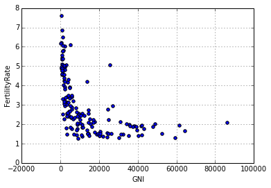

```python
WHO.plot('GNI', 'FertilityRate', kind = 'scatter')
```

## Subsetting

```python
Outliers = WHO[(WHO.GNI > 10000) & (WHO.FertilityRate > 2.5)]
Outliers.shape[0]
```

```
7
```

```python
Outliers[['Country','GNI','FertilityRate']]
```

|  | Country | GNI | FertilityRate |
| --- | --- | --- | --- |
| 22 | Botswana | 14550 | 2.71 |
| 55 | Equatorial Guinea | 25620 | 5.04 |
| 62 | Gabon | 13740 | 4.18 |
| 82 | Israel | 27110 | 2.92 |
| 87 | Kazakhstan | 11250 | 2.52 |
| 130 | Panama | 14510 | 2.52 |
| 149 | Saudi Arabia | 24700 | 2.76 |

# VIDEO 6

## Histograms

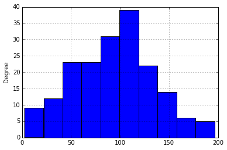

```python
WHO.plot(y = 'CellularSubscribers', kind = 'hist', legend = False)
```

## Boxplot

Using default settings

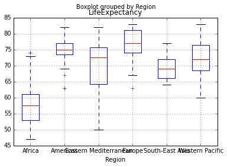

```python
WHO.boxplot('LifeExpectancy', by = 'Region')
```

tweaking the params a little bit to get a nicer plot  
The code is a bit messy....

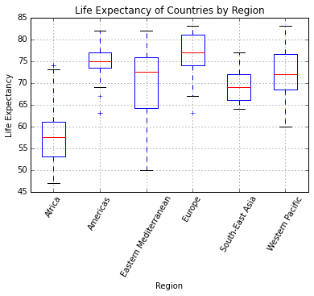

```python
fig = plt.figure()
WHO.boxplot('LifeExpectancy', by = 'Region', rot = 60)
plt.title("Life Expectancy of Countries by Region")
plt.suptitle("")
plt.ylabel("Life Expectancy")
```

## Summary Tables

A bit more complicated than in R

```python
WHO.groupby('Region').size()
```

```
Region
Africa                   46
Americas                 35
Eastern Mediterranean    22
Europe                   53
South-East Asia          11
Western Pacific          27
dtype: int64
```

```python
WHO.groupby('Region')['Over60'].mean()
```

```
Region
Africa                    5.220652
Americas                 10.943714
Eastern Mediterranean     5.620000
Europe                   19.774906
South-East Asia           8.769091
Western Pacific          10.162963
Name: Over60, dtype: float64
```

```python
WHO.groupby('Region')['LiteracyRate'].min()
```

```
Region
Africa                   31.1
Americas                 75.2
Eastern Mediterranean    63.9
Europe                   95.2
South-East Asia          56.8
Western Pacific          60.6
Name: LiteracyRate, dtype: float64
```